# MRNet - explatory data analysis (EDA)

This is one of a series of notebook I've created as part of participating in the [MRNet Competition](https://stanfordmlgroup.github.io/competitions/mrnet/).

In this notebook I performed an EDA on the MRNet Dataset.

To jump to the relevant section:

- Inspect dataset content
- Inspect MRI scan images
- Inspect csv files
- Investigate co-occurrence of conditions
- Resources

For other notebooks and code, please visit the [github repo](https://github.com/MisaOgura/MRNet).

## Background

In the paper [Deep-learning-assisted diagnosis for knee magnetic resonance imaging: Development and retrospective validation of MRNet](https://journals.plos.org/plosmedicine/article?id=10.1371/journal.pmed.1002699), the [Stanford ML Group](https://stanfordmlgroup.github.io/) developed an algorithm to predict abnormalities in knee MRI exams, and measured the clinical utility of providing the algorithm’s predictions to radiologists and surgeons during interpretation.

They developed a deep learning model for detecting:

- **general abnormalities**
- **anterior cruciate ligament (ACL)**
- **meniscal tears**

## MRNet Dataset description

The **dataset (~5.7G)** was released along with the publication of the paper. You can download it by agreeing to the Research Use Agreement and submitting your details on the [MRNet Competition](https://stanfordmlgroup.github.io/competitions/mrnet/) page.

It consists of **1,370 knee MRI exams**, containing:

- **1,104 (80.6%) abnormal exams**
- **319 (23.3%) ACL tears**
- **508 (37.1%) meniscal tears**

The dataset is split into:

- **training set (1,130 exams, 1,088 patients)**
- **validation set (120 exams, 111 patients)** - called *tuning set* in the paper
- **hidden test set (120 exams, 113 patients)** - called *validation set* in the paper

The hidden test set is *not publicly available* and is used for scoring models submitted for the competition.

N.B.

- [Stratified random sampling](https://en.wikipedia.org/wiki/Stratified_sampling) was used to ensure *at least 50 positive examples* of abnormal, ACL tear and meniscal tear were preset in each set.
- All exams from each patient were put in the same split.
- In the paper, an external validation was performed on a [publicly available data](http://www.riteh.uniri.hr/~istajduh/projects/kneeMRI/).

## Inspect dataset content

First thing first - let's inspect the content and familiarise ourselves with the dataset.

```python
!pip3 install seaborn
```

```
  Obtaining dependency information for seaborn from https://files.pythonhosted.org/packages/7b/e5/83fcd7e9db036c179e0352bfcd20f81d728197a16f883e7b90307a88e65e/seaborn-0.13.0-py3-none-any.whl.metadata
Using cached seaborn-0.13.0-py3-none-any.whl (294 kB)
```

```python
%config InlineBackend.figure_format = 'retina'
%matplotlib inline

import numpy as np
import pandas as pd
import seaborn as sns
import matplotlib.pyplot as plt

from glob import glob
```

```python
data_dir = 'MRNet-v1.0'

!ls -lh $data_dir
```

```
total 1141472
drwxr-xr-x@ 6 kaaviya  staff   192B Oct  1 14:34 train
-rw-r--r--@ 1 kaaviya  staff   7.7K Nov 25  2018 train-abnormal.csv
-rw-r--r--@ 1 kaaviya  staff   7.7K Nov 25  2018 train-acl.csv
-rw-r--r--@ 1 kaaviya  staff   7.7K Nov 25  2018 train-meniscus.csv
drwxr-xr-x@ 6 kaaviya  staff   192B Oct  1 14:34 valid
-rw-r--r--@ 1 kaaviya  staff   840B Nov 25  2018 valid-abnormal.csv
-rw-r--r--@ 1 kaaviya  staff   840B Nov 25  2018 valid-acl.csv
-rw-r--r--@ 1 kaaviya  staff   840B Nov 25  2018 valid-meniscus.csv
-rw-r--r--  1 kaaviya  staff   557M Nov  4 21:57 valid.zip
```

The dataset is made up of `train` and `valid` directories, as well as `csv` files for the diagnoses of the three conditions we're interested in.

## Inspect MRI scan images

For the time being, I'm going to focus on the `train` and `valid` directories, which contain MRI scan images.

```python
train_dir = f'{data_dir}/train'
valid_dir = f'{data_dir}/valid'

!ls -lh $train_dir $valid_dir
```

```
MRNet-v1.0/train:
total 0
drwxr-xr-x@ 1133 kaaviya  staff    35K Oct  1 14:34 axial
drwxr-xr-x@ 1133 kaaviya  staff    35K Oct  1 14:35 coronal
drwxr-xr-x@ 1133 kaaviya  staff    35K Oct  1 14:34 sagittal

MRNet-v1.0/valid:
total 0
drwxr-xr-x@ 122 kaaviya  staff   3.8K Feb  5  2019 axial
drwxr-xr-x@ 122 kaaviya  staff   3.8K Feb  5  2019 coronal
drwxr-xr-x@ 122 kaaviya  staff   3.8K Feb  5  2019 sagittal
```

```python
print('Check disk usage\n')
!du -h $train_dir $valid_dir
```

```
Check disk usage

2.4G	MRNet-v1.0/train/axial
2.1G	MRNet-v1.0/train/sagittal
2.1G	MRNet-v1.0/train/coronal
6.5G	MRNet-v1.0/train
258M	MRNet-v1.0/valid/axial
229M	MRNet-v1.0/valid/sagittal
221M	MRNet-v1.0/valid/coronal
708M	MRNet-v1.0/valid
```

```python
print(f'First 5 items in {train_dir}/axial/\n')
!ls $train_dir/axial | head -5
```

```
First 5 items in MRNet-v1.0/train/axial/

0000.npy
0001.npy
0002.npy
0003.npy
0004.npy
```

```python
planes = ['axial', 'coronal', 'sagittal']
datasets = {'train': train_dir, 'valid': valid_dir}

for dataset, path in datasets.items():
    print(f'\nNumber of exams in {dataset} set:')
    for plane in planes:
        print(plane, len(glob(f'{path}/{plane}/*.npy')))
```

```
Number of exams in train set:
axial 1130
coronal 1130
sagittal 1130

Number of exams in valid set:
axial 120
coronal 120
sagittal 120
```

So far, we've found that the `train` and `valid` sets are further divided into three planes - `axial`, `sagittal` and `coronal` - and each exam series is provided as a `npy` file.

We have also validated that the `train` and `valid` sets contain 1,130 and 120 exams, respectively.

Let's open a couple of them.

```python
train_axial_exams = glob(f'{train_dir}/axial/*.npy')[:5]

for exam in train_axial_exams:
    series = np.load(exam)
    print(series.shape)
```

```
(48, 256, 256)
(24, 256, 256)
(26, 256, 256)
(38, 256, 256)
(30, 256, 256)
```

```python
def plot_first_ten(path):
    series = np.load(path)[:10]

    fig = plt.figure(figsize=(20, 6))

    for i, image in enumerate(series):
        ax = fig.add_subplot(1, 10, i+1, xticks=[], yticks=[])
        plt.imshow(image, cmap='gray')
        plt.axis('off');
```

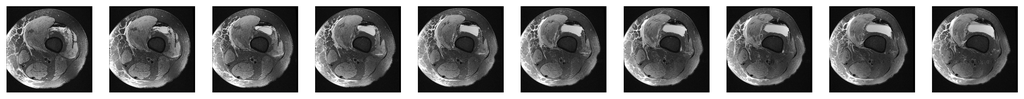

```python
plot_first_ten(train_axial_exams[0])
```

```python
valid_axial_exams = glob(f'{valid_dir}/axial/*.npy')[:5]
valid_axial_exams
```

```
['MRNet-v1.0/valid/axial/1139.npy',
 'MRNet-v1.0/valid/axial/1138.npy',
 'MRNet-v1.0/valid/axial/1249.npy',
 'MRNet-v1.0/valid/axial/1248.npy',
 'MRNet-v1.0/valid/axial/1207.npy']
```

```python
for exam in valid_axial_exams:
    series = np.load(exam)
    print(series.shape)
```

```
(33, 256, 256)
(28, 256, 256)
(20, 256, 256)
(35, 256, 256)
(24, 256, 256)
```

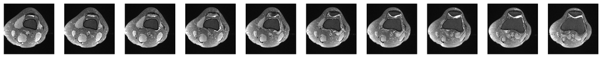

```python
plot_first_ten(valid_axial_exams[0])
```

## Visualise distrubutions of number of images in a series

According to the paper, the number of series in each exams varies from 17 to 61 (mean 31.48, SD 7.07).

Let's have a look at the distributions for `train` and `valid` datasets.

```python
def get_num_images_per_exam(exams):
    num_images_per_exam = []

    for exam in exams:
        series = np.load(exam)
        num_images_per_exam.append(series.shape[0])

    return np.asarray(num_images_per_exam)
```

```python
def plot_num_images_per_exam(dataset_path):
    f, axes = plt.subplots(1, 3, figsize=(20, 6), sharex=True)

    for i, plane in enumerate(planes):
        paths = glob(f'{dataset_path}/{plane}/*.npy')

        num_images = get_num_images_per_exam(paths)
        print(f'{plane} - min: {num_images.min()}, max: {num_images.max()}')

        sns.distplot(num_images, ax=axes[i])
        axes[i].set_title(f'{plane} plane')
```

### First, the `train` set:

```
axial - min: 19, max: 61
```

```
coronal - min: 17, max: 58
```

```
sagittal - min: 17, max: 51
```

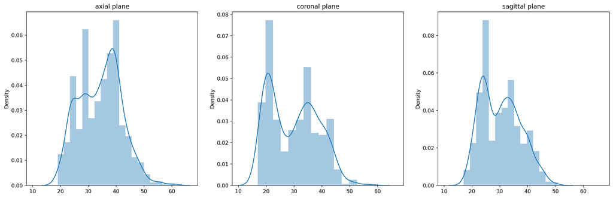

```python
plot_num_images_per_exam(train_dir)
```

### And for the `valid` set:

```
axial - min: 20, max: 52
coronal - min: 17, max: 48
sagittal - min: 21, max: 45
```

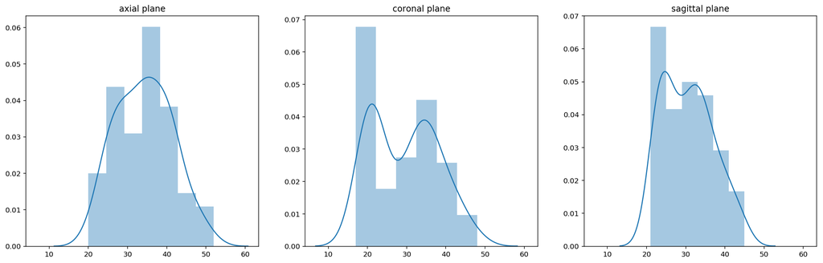

```python
plot_num_images_per_exam(valid_dir)
```

For each plane the distributions are somewhat similar between the training and validation set.

The majority of the cases, the number of images fall in between 20 and 40.

It's probably a good place to stop for now, as we've gained a good understanding of the MRI scan images.

## Inspect csv files

Let's move on and check out the `csv` files next.

```python
!find $data_dir -name "*.csv"
```

```
MRNet-v1.0/valid-abnormal.csv
MRNet-v1.0/train-acl.csv
MRNet-v1.0/train-meniscus.csv
MRNet-v1.0/valid-acl.csv
MRNet-v1.0/train-abnormal.csv
MRNet-v1.0/valid-meniscus.csv
```

### Train set: abnormal samples

```python
train_abnormal_df = pd.read_csv(f'{data_dir}/train-abnormal.csv',
                                header=None,
                                names=['case', 'abnormal'],
                                dtype={'case': str, 'abnormal': np.int64})
print(train_abnormal_df.groupby('abnormal').count())
print('\nMissing values: ', train_abnormal_df.isnull().values.any())
train_abnormal_df.head()
```

```
          case
abnormal
0          217
1          913

Missing values:  False
```

|  | case | abnormal |
| --- | --- | --- |
| 0 | 0000 | 1 |
| 1 | 0001 | 1 |
| 2 | 0002 | 1 |
| 3 | 0003 | 1 |
| 4 | 0004 | 1 |

### Train set: ACL tear

```python
train_acl_df = pd.read_csv(f'{data_dir}/train-acl.csv',
                           header=None,
                           names=['case', 'acl'],
                           dtype={'case': str, 'acl': np.int64})
print(train_acl_df.groupby('acl').count())
print('\nMissing values: ', train_acl_df.isnull().values.any())
train_acl_df.head()
```

```
     case
acl
0     922
1     208

Missing values:  False
```

|  | case | acl |
| --- | --- | --- |
| 0 | 0000 | 0 |
| 1 | 0001 | 1 |
| 2 | 0002 | 0 |
| 3 | 0003 | 0 |
| 4 | 0004 | 0 |

### Train set: meniscal tear

```python
train_meniscus_df = pd.read_csv(f'{data_dir}/train-meniscus.csv',
                                header=None,
                                names=['case', 'meniscus'],
                                dtype={'case': str, 'meniscus': np.int64})
print(train_meniscus_df.groupby('meniscus').count())
print('\nMissing values: ', train_meniscus_df.isnull().values.any())
train_meniscus_df.head()
```

```
          case
meniscus
0          733
1          397

Missing values:  False
```

|  | case | meniscus |
| --- | --- | --- |
| 0 | 0000 | 0 |
| 1 | 0001 | 1 |
| 2 | 0002 | 0 |
| 3 | 0003 | 1 |
| 4 | 0004 | 0 |

### Train set: merge labels

It would be handy to have labels for each condition per case in one place, so we will merge the three dataframes.

```python
train_df = pd.merge(train_abnormal_df, train_acl_df, on='case').merge(train_meniscus_df, on='case')
train_df.head()
```

|  | case | abnormal | acl | meniscus |
| --- | --- | --- | --- | --- |
| 0 | 0000 | 1 | 0 | 0 |
| 1 | 0001 | 1 | 1 | 1 |
| 2 | 0002 | 1 | 0 | 0 |
| 3 | 0003 | 1 | 0 | 1 |
| 4 | 0004 | 1 | 0 | 0 |

### Valid set: repeat the process

We will do the same for the `valid` set.

```python
valid_abnormal_df = pd.read_csv(f'{data_dir}/valid-abnormal.csv',
                                header=None,
                                names=['case', 'abnormal'],
                                dtype={'case': str, 'abnormal': np.int64})

valid_acl_df = pd.read_csv(f'{data_dir}/valid-acl.csv',
                           header=None,
                           names=['case', 'acl'],
                           dtype={'case': str, 'acl': np.int64})

valid_meniscus_df = pd.read_csv(f'{data_dir}/valid-meniscus.csv',
                                header=None,
                                names=['case', 'meniscus'],
                                dtype={'case': str, 'meniscus': np.int64})

valid_df = pd.merge(valid_abnormal_df, valid_acl_df, on='case').merge(valid_meniscus_df, on='case')
valid_df.head()
```

|  | case | abnormal | acl | meniscus |
| --- | --- | --- | --- | --- |
| 0 | 1130 | 0 | 0 | 0 |
| 1 | 1131 | 0 | 0 | 0 |
| 2 | 1132 | 0 | 0 | 0 |
| 3 | 1133 | 0 | 0 | 0 |
| 4 | 1134 | 0 | 0 | 0 |

## Investigate co-occurrence of conditions

We can now inspect co-occurrence of abnormalities, ACL tear and meniscal tear.

```python
pd.options.display.float_format = '{:,.1f}'.format

train_co_occurency_df = train_df.groupby(['abnormal', 'acl', 'meniscus']).count()
train_co_occurency_df['%_freq'] = (train_co_occurency_df.case / train_co_occurency_df.case.sum()) * 100
train_co_occurency_df.head()
```

| abnormal | acl | meniscus | case | %_freq |
| --- | --- | --- | --- | --- |
| 0 | 0 | 0 | 217 | 19.2 |
| 1 | 0 | 0 | 433 | 38.3 |
|  |  | 1 | 272 | 24.1 |
|  | 1 | 0 | 83 | 7.3 |
|  |  | 1 | 125 | 11.1 |

```python
valid_co_occurency_df = valid_df.groupby(['abnormal', 'acl', 'meniscus']).count()
valid_co_occurency_df['%_freq'] = (valid_co_occurency_df.case / valid_co_occurency_df.case.sum()) * 100
valid_co_occurency_df.head()
```

| abnormal | acl | meniscus | case | %_freq |
| --- | --- | --- | --- | --- |
| 0 | 0 | 0 | 25 | 20.8 |
| 1 | 0 | 0 | 20 | 16.7 |
|  |  | 1 | 21 | 17.5 |
|  | 1 | 0 | 23 | 19.2 |
|  |  | 1 | 31 | 25.8 |

It's worth noting that there are discrepancies between the `train` and `valid` datasets in terms of the frequency of co-occurrence of these conditions.

- Negative of all three
  - train: 19.2%
  - valid: 20.8%
- Abnormal, but no ACL tear and no meniscal tear
  - train: 38.3%
  - valid: 16.7%
- Abnormal with ACL tear, but no meniscal tear
  - train: 7.3%
  - valid: 19.2%
- Abnormal with meniscal tear, but no ACL tear
  - train: 24.1%
  - valid: 17.5%
- Positive of all three
  - train: 11.1%
  - valid: 25.8%

## Resources

[A Gentle Introduction to Exploratory Data Analysis](https://towardsdatascience.com/a-gentle-introduction-to-exploratory-data-analysis-f11d843b8184)

[Why you should start using .npy file more often…](https://towardsdatascience.com/why-you-should-start-using-npy-file-more-often-df2a13cc0161)